# Coursera-Cyclistc

2022-06-05

# COURSERA GOOGLE LEARNING WITH CYCLISTIC BIKE SHARES

## **The question we want to answer is:**

## HOW DO ANNUAL MEMBERS AND CASUAL RIDERS USE CYCLISTIC BIKES DIFFERENTLY?

*(We’re working with the fictional company Cyclistic, but the data has been anonymized, licensed, and provided to Google and Coursera from Motivate International Inc.)*

### SUMMARY / CONLUSIONS:

Our business task is to make sense of the available data on rides, working towards the goal of increasing Cyclistic membership.

The data sources used were the collection of .CSV files provided at this link: https://divvy-tripdata.s3.amazonaws.com/index.html

This R Markdown file provides a more detailed step-by-step of my thought process, approach, and how I did the data Extract / Transform / Load (ETL), then Exploratory Data Analysis (EDA), followed by data visualization (data viz) and drawing conclusions.

Data viz comes at the end of this R Markdown document.

## STEP 1: installing all relevant packages and libraries.

These are broken out in many individual library commands instead of comma-delimited lists just for readability.

For this project, we add the tidyverse, ggplot2, and lubridate on top of base R.

```r
install.packages("tidyverse")
```

Once packages are all installed, then it’s time to load the necessary libraries.

```r
library(tidyverse)
library(ggplot2)
library(lubridate)
library(readr)
library(lessR)
```

## STEP 2: Next, we Extract, Transform, and Load (ETL) and clean the data, starting with importing and converting .CSV’s into Tibbles.

Now that our packages and libraries are setup, we load/import the dataset(s).

We were given 4 separate .CSV sheets, each representing one quarter of 2019, totalling around ~3.8m rows and about 500 megabytes of data.

You could do a lot of this in SQL in a separate application, export as one large .CSV or .JSON, and then import that - depending on how large the export is.

One spreadsheet had the wrong column names, so I used Google BigQuery to rename them with a series of SELECT * EXCEPT … AS commands in Google BigQuery (because it does not support ALTER TABLE … RENAME AS). Once that was done, I combined all four spreadsheets in SQL using the “UNION ALL” function.

Unfortunately, BigQuery limits what you can export, so even though it is possible to make a single data table with ~3.8m rows and correct column headings, it is not possible to export it from BigQuery.

### Importing discrete .CSV’s and binding into one huge Tibble

That means we are importing four separate (properly-columned) .CSV files in R.

I use the “read_csv()” function from lessR for this.

```r
setwd("C:/Users/timot/Documents/R/Coursera")
importDF1 <- read_csv("Cyclistic19Q1.csv")
importDF2 <- read_csv("Cyclistic19Q2.csv")
importDF3 <- read_csv("Cyclistic19Q3.csv")
importDF4 <- read_csv("Cyclistic19Q4.csv")
```

We then convert these dataframes to Tibbles using “as_tibble()”.

```r
importTIB1 <- as_tibble(importDF1)
importTIB2 <- as_tibble(importDF2)
importTIB3 <- as_tibble(importDF3)
importTIB4 <- as_tibble(importDF4)
```

Once we have the imported Tibbles set up, we look at overall structure and properties.

We use “dim” to see how many rows and columns we have, followed by “str” to provide a high level explanation of each column’s data type. Then we use “glimpse” to preview the actual values in each row.

```r
dim(importTIB1)
```

```
## [1] 365069     12
```

```r
dim(importTIB2)
```

```
## [1] 1108163      12
```

```r
dim(importTIB3)
```

```
## [1] 1640718      12
```

```r
dim(importTIB4)
```

```
## [1] 704054     12
```

```r
str(importTIB1)
```

```
## tibble [365,069 x 12] (S3: tbl_df/tbl/data.frame)
##  $ trip_id          : num [1:365069] 21742443 21742444 21742445 21742446 21742447 ...
##  $ start_time       : POSIXct[1:365069], format: "2019-01-01 00:04:37" "2019-01-01 00:08:13" ...
##  $ end_time         : POSIXct[1:365069], format: "2019-01-01 00:11:07" "2019-01-01 00:15:34" ...
##  $ bikeid           : num [1:365069] 2167 4386 1524 252 1170 ...
##  $ tripduration     : num [1:365069] 390 441 829 1783 364 ...
##  $ from_station_id  : num [1:365069] 199 44 15 123 173 98 98 211 150 268 ...
##  $ from_station_name: chr [1:365069] "Wabash Ave & Grand Ave" "State St & Randolph St" "Racine Ave & 18th St" "California Ave & Milwaukee Ave" ...
##  $ to_station_id    : num [1:365069] 84 624 644 176 35 49 49 142 148 141 ...
##  $ to_station_name  : chr [1:365069] "Milwaukee Ave & Grand Ave" "Dearborn St & Van Buren St (*)" "Western Ave & Fillmore St (*)" "Clark St & Elm St" ...
##  $ usertype         : chr [1:365069] "Subscriber" "Subscriber" "Subscriber" "Subscriber" ...
##  $ gender           : chr [1:365069] "Male" "Female" "Female" "Male" ...
##  $ birthyear        : num [1:365069] 1989 1990 1994 1993 1994 ...
```

```r
str(importTIB2)
```

```
## tibble [1,108,163 x 12] (S3: tbl_df/tbl/data.frame)
##  $ trip_id          : num [1:1108163] 22178546 22178552 22178594 22178628 22178647 ...
##  $ start_time       : chr [1:1108163] "2019-04-01 01:53:56 UTC" "2019-04-01 02:58:12 UTC" "2019-04-01 05:22:43 UTC" "2019-04-01 05:47:24 UTC" ...
##  $ end_time         : chr [1:1108163] "2019-04-01 02:03:02 UTC" "2019-04-01 03:09:14 UTC" "2019-04-01 05:33:05 UTC" "2019-04-01 05:54:23 UTC" ...
##  $ bikeid           : num [1:1108163] 5351 1167 4650 4535 4666 ...
##  $ tripduration     : num [1:1108163] 546 662 622 419 352 1030 998 634 965 313 ...
##  $ from_station_id  : num [1:1108163] 59 304 118 43 232 481 89 192 91 174 ...
##  $ from_station_name: chr [1:1108163] "Wabash Ave & Roosevelt Rd" "Broadway & Waveland Ave" "Sedgwick St & North Ave" "Michigan Ave & Washington St" ...
##  $ to_station_id    : num [1:1108163] 36 246 125 98 296 481 55 196 383 37 ...
##  $ to_station_name  : chr [1:1108163] "Franklin St & Jackson Blvd" "Ashland Ave & Belle Plaine Ave" "Rush St & Hubbard St" "LaSalle St & Washington St" ...
##  $ usertype         : chr [1:1108163] "Subscriber" "Subscriber" "Subscriber" "Subscriber" ...
##  $ gender           : chr [1:1108163] "Male" "Female" "Male" "Male" ...
##  $ birthyear        : num [1:1108163] 1958 1959 1957 1958 1955 ...
```

```r
str(importTIB3)
```

```
## tibble [1,640,718 x 12] (S3: tbl_df/tbl/data.frame)
##  $ trip_id          : num [1:1640718] 23479388 23479389 23479390 23479391 23479392 ...
##  $ start_time       : POSIXct[1:1640718], format: "2019-07-01 00:00:27" "2019-07-01 00:01:16" ...
##  $ end_time         : POSIXct[1:1640718], format: "2019-07-01 00:20:41" "2019-07-01 00:18:44" ...
##  $ bikeid           : num [1:1640718] 3591 5353 6180 5540 6014 ...
##  $ tripduration     : num [1:1640718] 1214 1048 1554 1503 1213 ...
##  $ from_station_id  : num [1:1640718] 117 381 313 313 168 300 168 313 43 43 ...
##  $ from_station_name: chr [1:1640718] "Wilton Ave & Belmont Ave" "Western Ave & Monroe St" "Lakeview Ave & Fullerton Pkwy" "Lakeview Ave & Fullerton Pkwy" ...
##  $ to_station_id    : num [1:1640718] 497 203 144 144 62 232 62 144 195 195 ...
##  $ to_station_name  : chr [1:1640718] "Kimball Ave & Belmont Ave" "Western Ave & 21st St" "Larrabee St & Webster Ave" "Larrabee St & Webster Ave" ...
##  $ usertype         : chr [1:1640718] "Subscriber" "Customer" "Customer" "Customer" ...
##  $ gender           : chr [1:1640718] "Male" NA NA NA ...
##  $ birthyear        : num [1:1640718] 1992 NA NA NA NA ...
```

```r
str(importTIB4)
```

```
## tibble [704,054 x 12] (S3: tbl_df/tbl/data.frame)
##  $ trip_id          : num [1:704054] 25223640 25223641 25223642 25223643 25223644 ...
##  $ start_time       : POSIXct[1:704054], format: "2019-10-01 00:01:39" "2019-10-01 00:02:16" ...
##  $ end_time         : POSIXct[1:704054], format: "2019-10-01 00:17:20" "2019-10-01 00:06:34" ...
##  $ bikeid           : num [1:704054] 2215 6328 3003 3275 5294 ...
##  $ tripduration     : num [1:704054] 940 258 850 2350 1867 ...
##  $ from_station_id  : num [1:704054] 20 19 84 313 210 156 84 156 156 336 ...
##  $ from_station_name: chr [1:704054] "Sheffield Ave & Kingsbury St" "Throop (Loomis) St & Taylor St" "Milwaukee Ave & Grand Ave" "Lakeview Ave & Fullerton Pkwy" ...
##  $ to_station_id    : num [1:704054] 309 241 199 290 382 226 142 463 463 336 ...
##  $ to_station_name  : chr [1:704054] "Leavitt St & Armitage Ave" "Morgan St & Polk St" "Wabash Ave & Grand Ave" "Kedzie Ave & Palmer Ct" ...
##  $ usertype         : chr [1:704054] "Subscriber" "Subscriber" "Subscriber" "Subscriber" ...
##  $ gender           : chr [1:704054] "Male" "Male" "Female" "Male" ...
##  $ birthyear        : num [1:704054] 1987 1998 1991 1990 1987 ...
```

We see that all the data types are the same and ready for merging, except for one: in importDF2, the columns “start_time” and “end time” are both characters instead of date/time format. These are four large files so instead of showing all the results of “dim” and “str”, rest assured that all column names now match! Next we do some data wrangling - specifically, we combine all four Tibbles into one giant Tibble.

```r
importTIB2$start_time <- as.POSIXct(importTIB2$start_time, format = "%Y-%m-%d %H:%M:%S")
importTIB2$end_time <- as.POSIXct(importTIB2$start_time, format = "%Y-%m-%d %H:%M:%S")
all_trips <- bind_rows(importTIB1, importTIB2, importTIB3, importTIB4)

dim(all_trips)
```

```
## [1] 3818004      12
```

```r
str(all_trips)
```

```
## tibble [3,818,004 x 12] (S3: tbl_df/tbl/data.frame)
##  $ trip_id          : num [1:3818004] 21742443 21742444 21742445 21742446 21742447 ...
##  $ start_time       : POSIXct[1:3818004], format: "2019-01-01 00:04:37" "2019-01-01 00:08:13" ...
##  $ end_time         : POSIXct[1:3818004], format: "2019-01-01 00:11:07" "2019-01-01 00:15:34" ...
##  $ bikeid           : num [1:3818004] 2167 4386 1524 252 1170 ...
##  $ tripduration     : num [1:3818004] 390 441 829 1783 364 ...
##  $ from_station_id  : num [1:3818004] 199 44 15 123 173 98 98 211 150 268 ...
##  $ from_station_name: chr [1:3818004] "Wabash Ave & Grand Ave" "State St & Randolph St" "Racine Ave & 18th St" "California Ave & Milwaukee Ave" ...
##  $ to_station_id    : num [1:3818004] 84 624 644 176 35 49 49 142 148 141 ...
##  $ to_station_name  : chr [1:3818004] "Milwaukee Ave & Grand Ave" "Dearborn St & Van Buren St (*)" "Western Ave & Fillmore St (*)" "Clark St & Elm St" ...
##  $ usertype         : chr [1:3818004] "Subscriber" "Subscriber" "Subscriber" "Subscriber" ...
##  $ gender           : chr [1:3818004] "Male" "Female" "Female" "Male" ...
##  $ birthyear        : num [1:3818004] 1989 1990 1994 1993 1994 ...
```

```r
glimpse(all_trips)
```

```
## Rows: 3,818,004
## Columns: 12
## $ trip_id           <dbl> 21742443, 21742444, 21742445, 21742446, 21742447, 21~
## $ start_time        <dttm> 2019-01-01 00:04:37, 2019-01-01 00:08:13, 2019-01-0~
## $ end_time          <dttm> 2019-01-01 00:11:07, 2019-01-01 00:15:34, 2019-01-0~
## $ bikeid            <dbl> 2167, 4386, 1524, 252, 1170, 2437, 2708, 2796, 6205,~
## $ tripduration      <dbl> 390, 441, 829, 1783, 364, 216, 177, 100, 1727, 336, ~
## $ from_station_id   <dbl> 199, 44, 15, 123, 173, 98, 98, 211, 150, 268, 299, 2~
## $ from_station_name <chr> "Wabash Ave & Grand Ave", "State St & Randolph St", ~
## $ to_station_id     <dbl> 84, 624, 644, 176, 35, 49, 49, 142, 148, 141, 295, 4~
## $ to_station_name   <chr> "Milwaukee Ave & Grand Ave", "Dearborn St & Van Bure~
## $ usertype          <chr> "Subscriber", "Subscriber", "Subscriber", "Subscribe~
## $ gender            <chr> "Male", "Female", "Female", "Male", "Male", "Female"~
## $ birthyear         <dbl> 1989, 1990, 1994, 1993, 1994, 1983, 1984, 1990, 1995~
```

Success! We now have one single Tibble with 3,818,004 observations of 12 variables. First, we want to backup the large imported Tibble before further manipulation, so we can refer back to if needed after the next steps, without having to redo the combining / mutating.

```r
all_trips_backup <- as_tibble(all_trips)
write_csv(all_trips_backup, "all_trips_backup.csv")
```

### Renaming and removing columns as necessary for this dataset.

After that, we rename column variables in our all_trips Tibble to match the guide’s conventions; because we have many packages loaded, we specify that it is the “dplyr::rename” function.

After that, we cut the columns “gender” and “birthyear”, per the guide.

And then, we fix an issue in the “member_casual” column. There are two names for members (“member” and “Subscriber”) and two names for casual riders (“Customer” and “casual”). We consolidate that from four to two labels by replacing “Subscriber” with “member” and “Customer” with “casual”.

```r
(all_trips <- dplyr::rename(all_trips
    ,ride_id = trip_id
    ,rideable_type = bikeid
    ,started_at = start_time
    ,ended_at = end_time
    ,start_station_name = from_station_name
    ,start_station_id = from_station_id
    ,end_station_name = to_station_name
    ,end_station_id = to_station_id
    ,member_casual = usertype))
```

```
## # A tibble: 3,818,004 x 12
##     ride_id started_at          ended_at            rideable_type tripduration
##       <dbl> <dttm>              <dttm>                      <dbl>        <dbl>
##  1 21742443 2019-01-01 00:04:37 2019-01-01 00:11:07          2167          390
##  2 21742444 2019-01-01 00:08:13 2019-01-01 00:15:34          4386          441
##  3 21742445 2019-01-01 00:13:23 2019-01-01 00:27:12          1524          829
##  4 21742446 2019-01-01 00:13:45 2019-01-01 00:43:28           252         1783
##  5 21742447 2019-01-01 00:14:52 2019-01-01 00:20:56          1170          364
##  6 21742448 2019-01-01 00:15:33 2019-01-01 00:19:09          2437          216
##  7 21742449 2019-01-01 00:16:06 2019-01-01 00:19:03          2708          177
##  8 21742450 2019-01-01 00:18:41 2019-01-01 00:20:21          2796          100
##  9 21742451 2019-01-01 00:18:43 2019-01-01 00:47:30          6205         1727
## 10 21742452 2019-01-01 00:19:18 2019-01-01 00:24:54          3939          336
## # ... with 3,817,994 more rows, and 7 more variables: start_station_id <dbl>,
## #   start_station_name <chr>, end_station_id <dbl>, end_station_name <chr>,
## #   member_casual <chr>, gender <chr>, birthyear <dbl>
```

```r
all_trips <- all_trips %>%
  select(-c(birthyear, gender))

all_trips <-  all_trips %>%
  mutate(member_casual = dplyr::recode(member_casual, "Subscriber" = "member" ,"Customer" = "casual"))
```

### Adding useful / calculated columns that we can use for our analysis.

The next and final step of our ETL of this data is to have some calculated columns and data aggregation.

```r
all_trips$date <- as.Date(all_trips$started_at)
all_trips$month <- format(as.Date(all_trips$date), "%m")
all_trips$day <- format(as.Date(all_trips$date), "%d")
all_trips$year <- format(as.Date(all_trips$date), "%Y")
all_trips$day_of_week <- format(as.Date(all_trips$date), "%A")
```

We next add a “ride_length”, in seconds, calculated column; it comes out as character, so we make it a Factor to easily convert it to numeric. Next, we convert from seconds to minutes by dividing by 60 with another calculated column. Then, we delete the old, redundant “tripduration” field. Finally, we’ll get rid of ride lengths with negative values (when the bikes were not in use), and then do a final backup to CSV of our cleaned and ready-for-analysis data.

```r
all_trips$ride_length <- difftime(all_trips$ended_at,all_trips$started_at)
all_trips$ride_length <- as.numeric(as.character(all_trips$ride_length))
all_trips <- all_trips[!(all_trips$start_station_name == "HQ QR" | all_trips$ride_length<0),]
all_trips <- all_trips %>%
  mutate(ride_length_mins = ride_length / 60)
all_trips <- all_trips %>%
  select(-c(tripduration))
```

```r
sum(all_trips$ride_length == 0)
```

```
## [1] 1108163
```

```r
all_trips <- all_trips[!(all_trips$ride_length==0),]
write_csv(all_trips, "all_trips_cleaned.csv")
```

There we go!

## STEP 3: Now that our data is loaded, cleaned, and backed up, it’s time for Exploratory Data Analysis (EDA).

First, our focus is going to be primarily on ride length, and how that varies by casual users versus members. Let’s run some basic descriptive statistics on ride length versus “member” or “casual”.

```r
summary(all_trips$ride_length)
```

```
##     Min.  1st Qu.   Median     Mean  3rd Qu.     Max.
##       61      406      697     1501     1257 10632022
```

```r
aggregate(all_trips$ride_length ~ all_trips$member_casual, FUN = mean)
```

```
##   all_trips$member_casual all_trips$ride_length
## 1                  casual             3634.3012
## 2                  member              866.5076
```

```r
aggregate(all_trips$ride_length ~ all_trips$member_casual, FUN = median)
```

```
##   all_trips$member_casual all_trips$ride_length
## 1                  casual                  1510
## 2                  member                   581
```

```r
aggregate(all_trips$ride_length ~ all_trips$member_casual, FUN = max)
```

```
##   all_trips$member_casual all_trips$ride_length
## 1                  casual              10632022
## 2                  member               9056634
```

```r
aggregate(all_trips$ride_length ~ all_trips$member_casual, FUN = min)
```

```
##   all_trips$member_casual all_trips$ride_length
## 1                  casual                    61
## 2                  member                    61
```

```r
aggregate(all_trips$ride_length ~ all_trips$member_casual, FUN = range)
```

```
##   all_trips$member_casual all_trips$ride_length.1 all_trips$ride_length.2
## 1                  casual                      61                10632022
## 2                  member                      61                 9056634
```

```r
aggregate(all_trips$ride_length ~ all_trips$member_casual, FUN = IQR)
```

```
##   all_trips$member_casual all_trips$ride_length
## 1                  casual                  1741
## 2                  member                   595
```

```r
aggregate(all_trips$ride_length ~ all_trips$member_casual, FUN = sd)
```

```
##   all_trips$member_casual all_trips$ride_length
## 1                  casual              64359.61
## 2                  member              17332.34
```

**This shows us that generally speaking, casual riders … 1. have much more variance in their rides, and 2. also tend to take longer rides, on average.**

Let’s look at the average ride time by each day for members vs casual users. R consistently threw up errors I couldn’t resolve with this output, so I sadly had to copy/paste into Excel and save this table as a .CSV, then re-import it.

```r
trips_weekday <- read_csv("C:/Users/timot/Documents/R/Coursera/trips_weekday.csv")
View(trips_weekday)
```

```r
avg_by_weekday <- aggregate(all_trips$ride_length_mins ~ all_trips$day_of_week, FUN = mean)
avg_by_weekday <- dplyr::rename(avg_by_weekday, "day" = "all_trips$day_of_week")
avg_by_weekday <- dplyr::rename(avg_by_weekday, "length" = "all_trips$ride_length_mins")
```

Let’s visualize that.

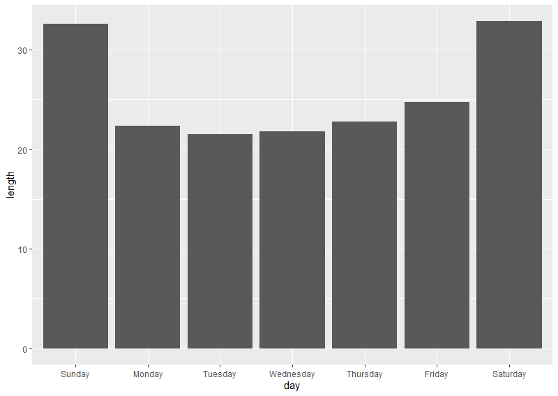

Basic bar chart of the weekday average ride lengths.

We can see that we have some pretty significant differences by day of the week: the weekends have the most minutes ridden, on average.

When we look at the average ride length by day of week and by membership, we can see even bigger differences.

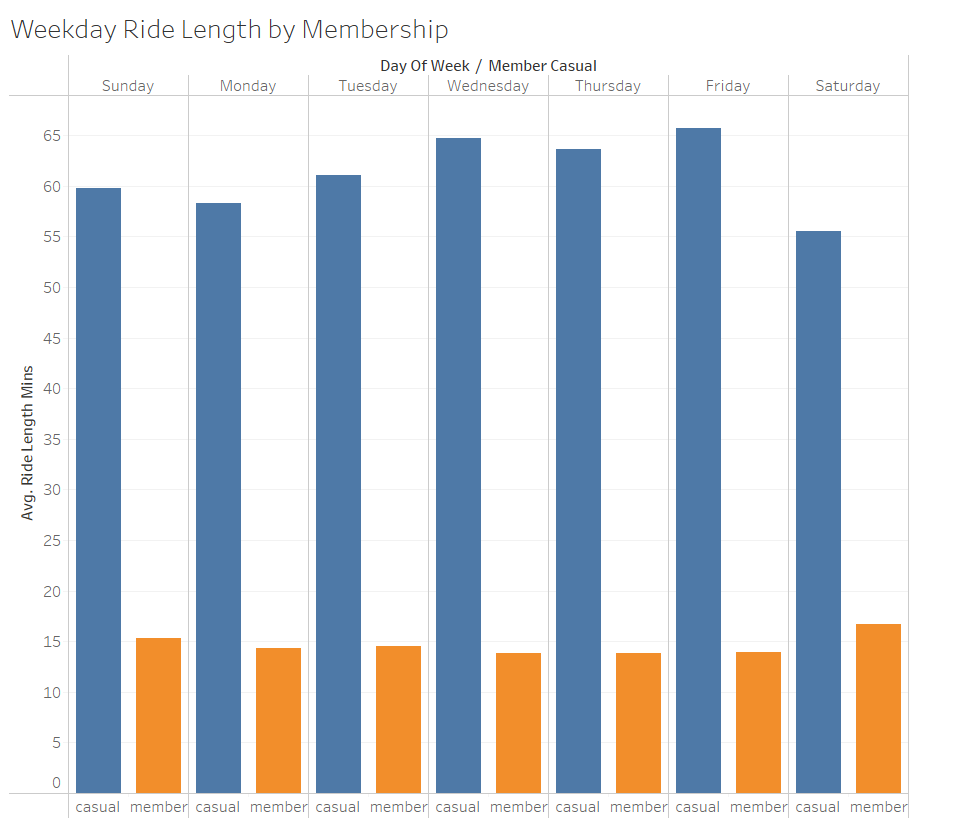

Bar chart of weekday average ride lengths, by membership.

This reinforces the fact that we have serious differences in each ride length: non-members take much longer rides when they rent bikes.

However, let’s look at the total rides taken overall; we can see that when looking at rides themselves, not minutes ridden, members actually comprise a very large percent of all rides.

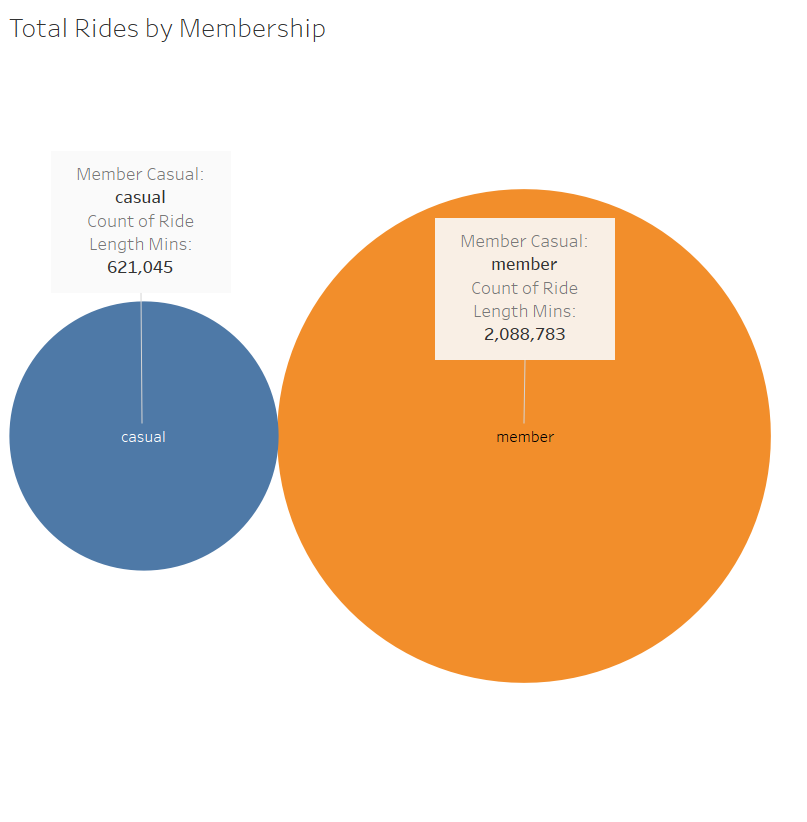

All rides (not minutes), by members and non-members.

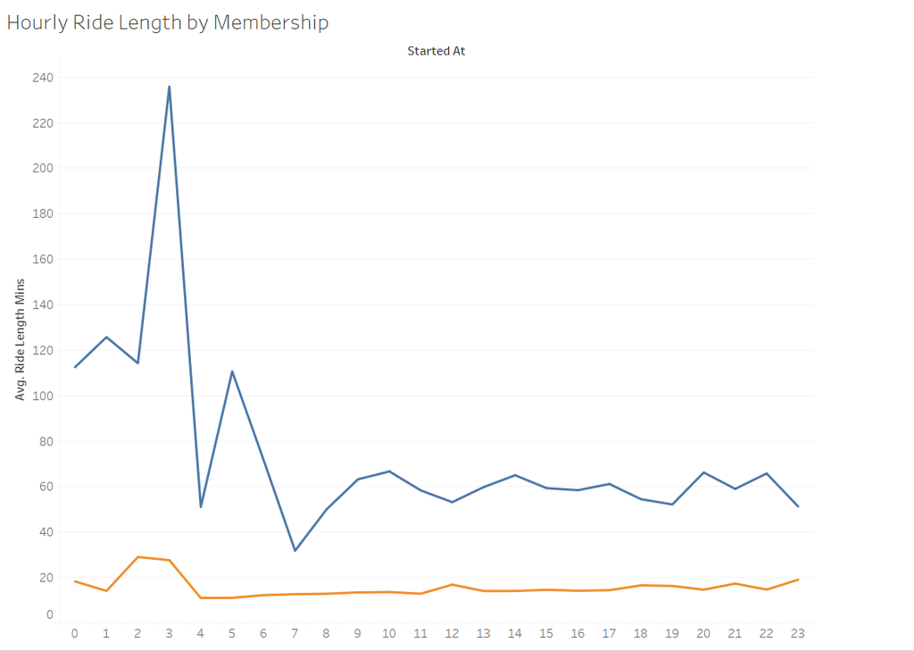

Average ride length by hour of the day, and by membership

Zooming back out from hours and days, let’s look at monthly trends over the course of one calendar year.

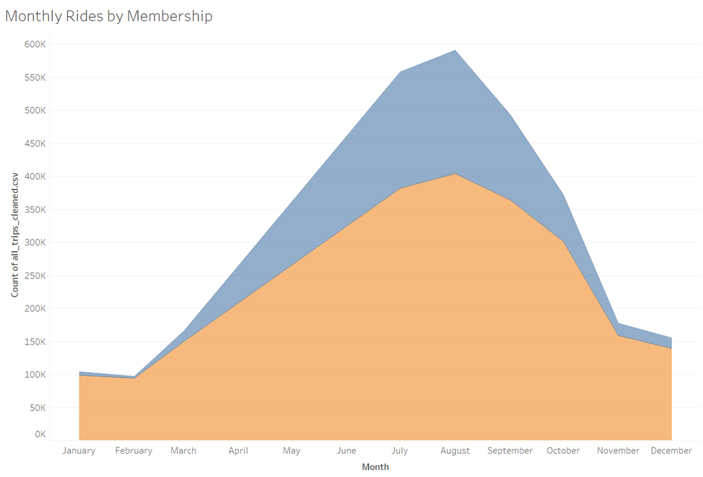

All bike rides (not minutes) by month and by membership

While members still comprise a majority of rides through the year, the busiest months of July, August, and September see total rides (not minutes ridden) surge for casual riders.

The rides by casual members in colder months make up only a tiny fraction of total rides, and members make up almost all of the cold month rides.